# Project 1, Applied Data Science

Tushar Ponkshe

Due: 9/18/2019

## Introduction

The starter code in Text_Processing.Rmd cleans the original dataset by removing stop words and performing various preprocessing tasks such as converting all the lyrics to the lower case, removing punctuation, numbers, empty words, extra white spaces, and stemming. The cleaned version of data is then saved as a RData file.

## EDA

First, I read the preprocessed csv file “processed_lyrics.RData”. We can see that the dataset contains 125,704 rows and 11 columns or features.

```
## [1] 125704     11
```

We can also check the structure of the stemmed lyrics -

```
##  chr "stop house call home rundown grass overgrown screen door wind heard call hold change fast love finally inside bedroom door cry home empty prove wrong"
```

We can see that the lyrics have been successfully stemmed and don’t contain any stop words.

##### What’s the distribution of number of songs over 5 decades?

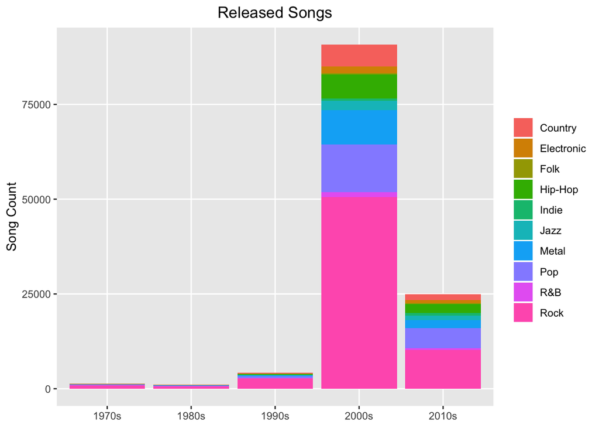

The plot above shows that the most active decade was 2000s, with Rock being the most popular genre.

$~$

#### What are the songs with most number words?

```
## # A tibble: 10 x 4
##    song                                   artist           genre  num_words
##    <chr>                                  <chr>            <chr>      <int>
##  1 yes-sir-i-will                         crass            Rock        2440
##  2 because-the-internet-screenplay-part-2 childish-gambino Hip-H…      1711
##  3 b-boy-bouillabaisse                    beastie-boys     Hip-H…      1310
##  4 rip-vs-poet-laurette                   canibus          Hip-H…      1134
##  5 because-the-internet-screenplay-part-4 childish-gambino Hip-H…      1071
##  6 crimson-ii                             edge-of-sanity   Metal       1053
##  7 hell-frezes-over-album                 the-eagles       Rock        1044
##  8 crimson-ii-incantation                 edge-of-sanity   Metal       1033
##  9 hypnagogue                             current-93       Folk         970
## 10 magica                                 dio              Rock         924
```

It’s interesting to see that songs in top 5 are mostly hip-hop. This is an expected result because rap songs are often categorized as hip-hop.

#### What is the distribution of word count across genres?

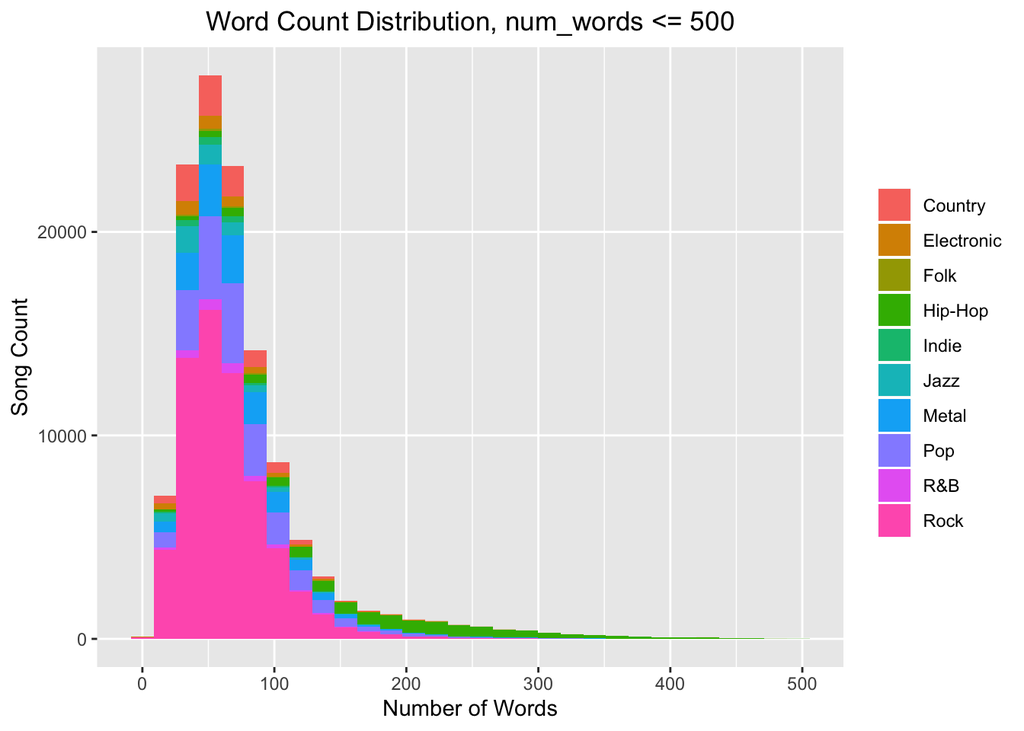

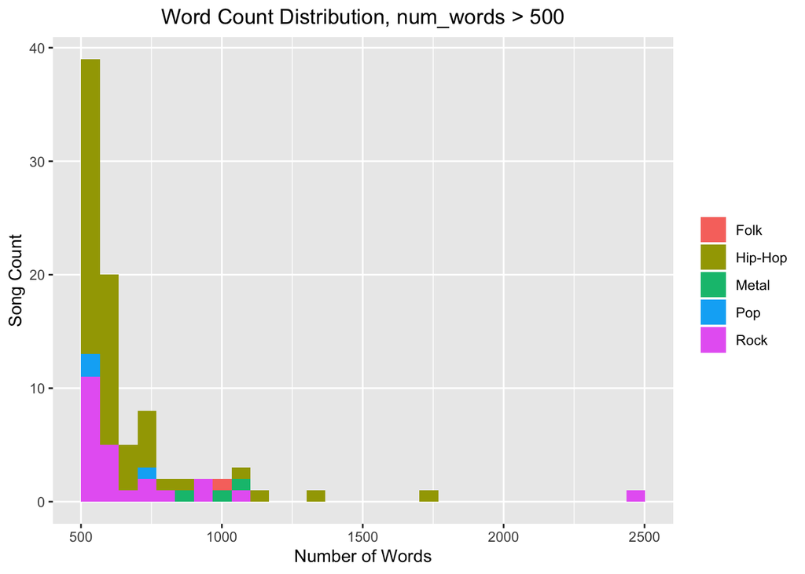

The first histogram of songs with fewer than 500 words is very skewed to the right, meaning that most songs tend to have 0-200 words.

The second histogram, also skewed to the right, shows that very few songs have more than 500 words. The ones that do are mostly hip-hop, given its rap style.

$~$

#### What are the most frequently used words?

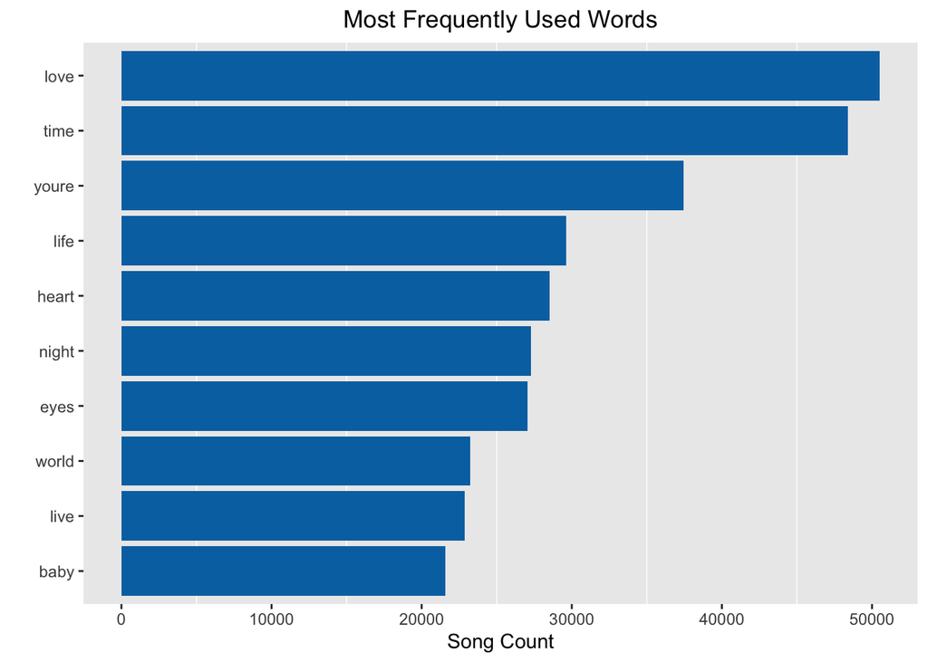

The above figure shows the top 10 most common words in the lyrics dataset.

$~$

#### Word Cloud #1: Most frequently used words in corpus**

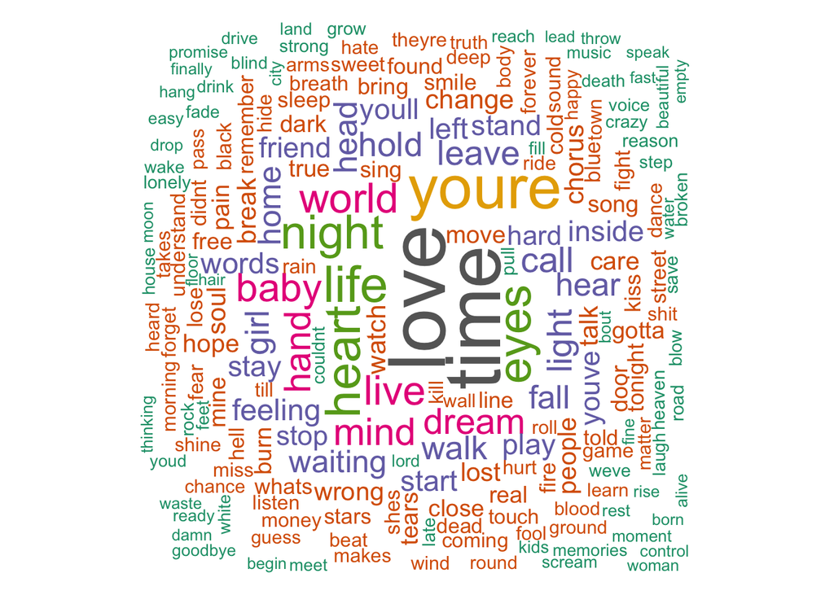

Words that are most frequently used are in the center and have bigger fonts. Each color represents groups of word that have similar frequencies. Frequency decreases as we move away from the center.

#### What are the most frequent words in each genre?

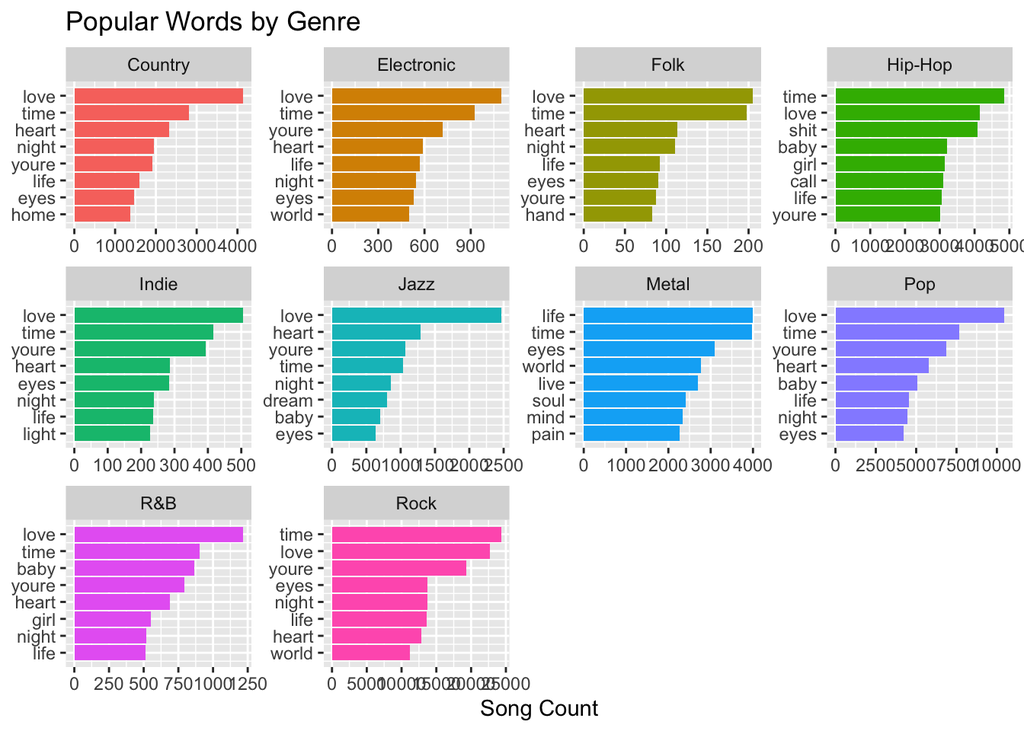

$~$

#### What are the most frequent words in each decade?

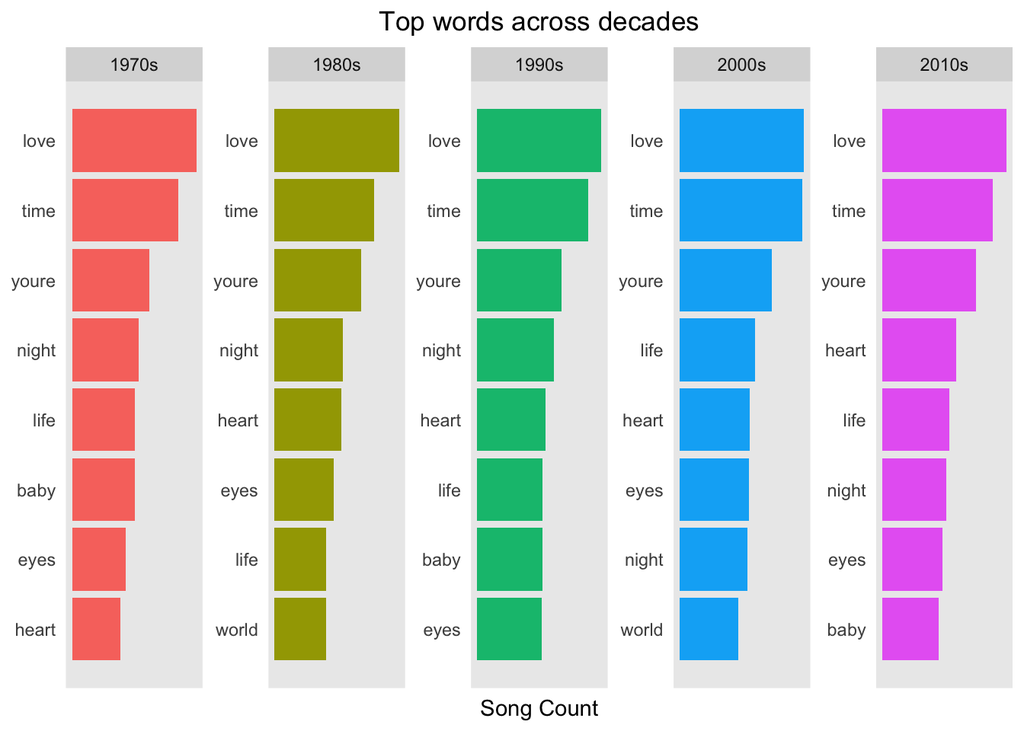

We see a similar trend – words like love, time, and heart appear in all decades, with order slightly changed.

$~$

#### What is the length of individual words?

We can also see length of individual words used in songs

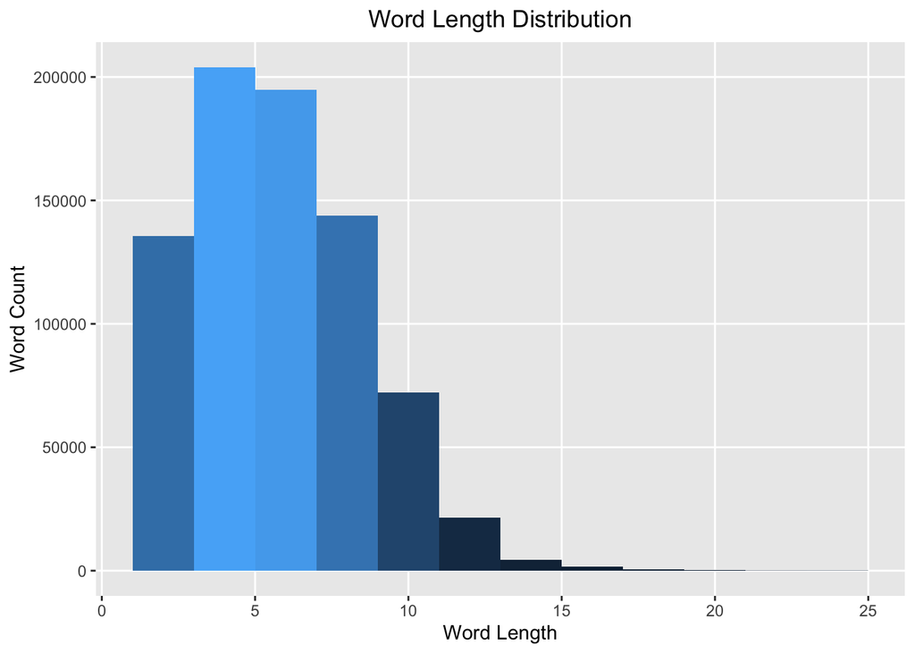

We observe that the histogram is skewed to the right, meaning that most words are less than 15 letters. This makes sense because longer words are not very common and are very hard to rhyme.

It’s interesting to see what these long words are through a wordcloud –>

#### Word Cloud #2: What are these really long words?**

[interactive chart not shown]

Most of these words contain repeated letters; these words may have been used to complement tune and rythm; not so much for conveying meaning. Also, some of these words have resulted from combining multiple words which also means that they’re not for conveying meaning.

$~$

## Word Cloud #3 - top words grouped by emotions

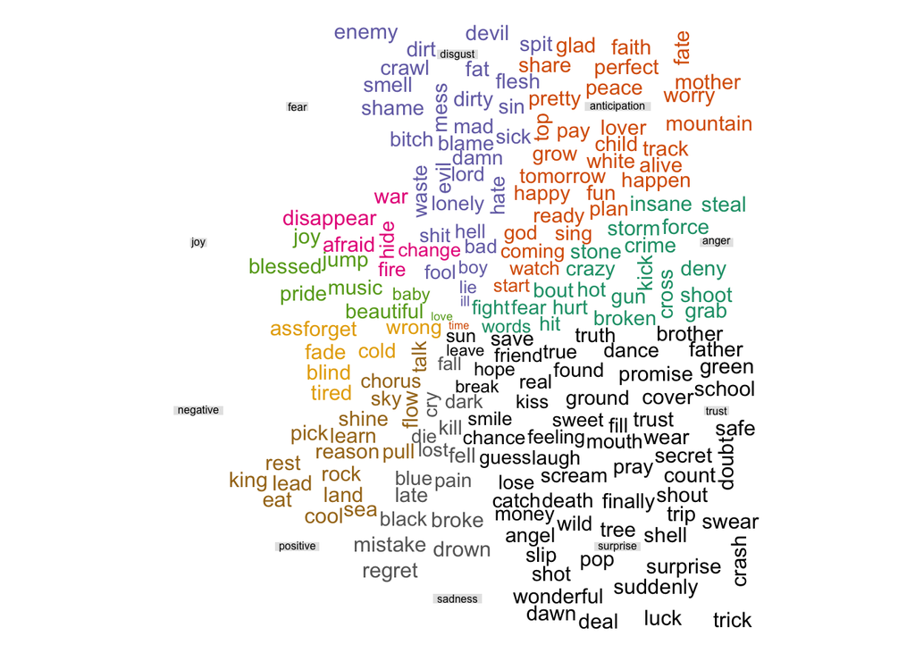

#### What are some positive and negative words in the corpus according to bing dictionary?

```
## # A tibble: 470,865 x 3
## # Groups:   id [117,930]
##        id word          n
##     <int> <chr>     <int>
##  1  99927 white       170
##  2  99931 white       170
##  3  14877 jump        125
##  4  14909 jump        125
##  5  61001 beautiful   109
##  6 119469 joy         101
##  7  15003 love         95
##  8  75038 dance        94
##  9  85460 love         86
## 10  47379 love         84
## # … with 470,855 more rows
```

```
## # A tibble: 11 x 4
##       id word  sentiment     n
##    <int> <chr> <chr>     <int>
##  1 50973 fall  negative     95
##  2 51043 fall  negative     95
##  3 71511 free  positive     94
##  4 77040 kill  negative     91
##  5 77050 kill  negative     91
##  6 61966 lie   negative     90
##  7 19585 ding  negative     88
##  8 76512 bitch negative     88
##  9 85460 love  positive     86
## 10 38530 crazy negative     84
## 11 47379 love  positive     84
```

The dictionary correctly categorized most words in the corpus. Words like “free” and “love” are positive, while the words “kill”, “lie” are negative.

## Highest tf-idf words, grouped by genre

Term-frequency-inverse document frequency (TF-IDF) is another way to judge the topic of an article by the words it contains. With TF-IDF, words are given weight – TF-IDF measures relevance, not frequency. That is, wordcounts are replaced with TF-IDF scores across the whole dataset.

In the figure below, we see words that are most relevant to the genres, instead of words most frequent within genres.

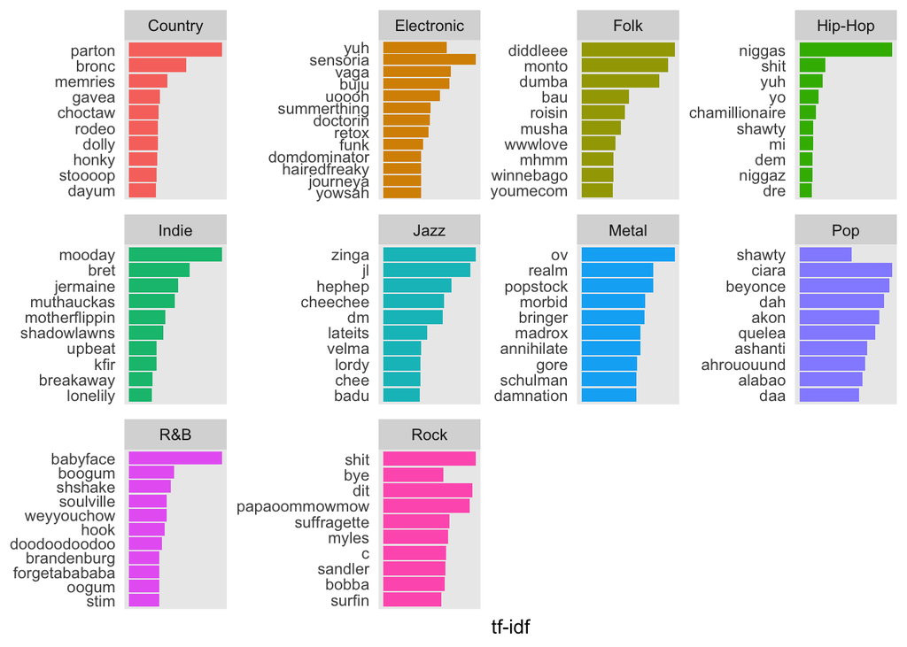

## Conclusion

**In this project report I have explored various trends in the lyrics data. Some of the topics I have explored are listed below:**

- EDA
- Distribution of number of songs over 5 decades
- Songs with most number of words
- Distribution of word count across genres
- Most frequently used words in coupus (with wordcloud)
- Most frequent words in each genre
- Most frequent words in each decade
- Length of individual words and identifying really long words (wordcloud)
- Words groupd by emotions (wordcloud)
- Identifying some positive/negative words in corpus according to bing dictionary
- TF-IDF words across genres

**Limitations and Future Directions**

- Wordcloud #2 suggests possible issues with data entry
- In the future I hope to do an in-depth analysis of artists in each genre over 5 decades
- The artists.csv file contains artists’s locations, origin etc which can be used for further analysis

## Resources used

- https://towardsdatascience.com/text-analysis-of-successful-song-lyrics-e41a4ccb26f5
- https://www.datacamp.com/community/tutorials/R-nlp-machine-learning
- https://www.tidytextmining.com/topicmodeling.html